# Can You Bake The Optimal Cake?

Victor A. Davis

#### Riddler Solution for August 26<sup>th</sup>, 2016

[Original Problem Statement:](http://fivethirtyeight.com/features/can-you-bake-the-optimal-cake/)

*A mathematician who has a birthday coming up asks his students to make him a cake. He is very particular (he is a constructive set theorist, which explains a lot) and asks his students to make him a three-layer cake that fits under a hollow glass cone he has on his desk. (The cone was given to him as a prize for proving an obscure theorem long ago.) He requires that the cake fill up the maximum amount of volume under the cone as possible and that the layers of the cake have straight vertical sides. (Again, the guy’s particular.) What are the thicknesses of the three layers of the cake in terms of the height of the glass cone? What percentage of the cone’s volume does the cake fill?*

*Here’s an example of what the cake could look like:*

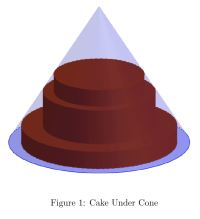

*Extra credit: What if he had asked for an N-layer cake?*

#### My Solution

WLOG, let $r=h=1$. Define $\vec{h} = (h_1, h_2, h_3, ..., h_n)$ the heights from the *base* of the various cylinders, in descending order, $h_1 \gt h_2 \gt h_3 \gt ... \gt h_n$. The volume of the whole cake is $\pi (1-h_1)^2(h_1-h_2) + \pi (1-h_2)^2(h_2-h_3) + ... + \pi (1-h_n)^2h_n$. We’ll eliminate the pesky $\pi$ and seek to maximize $V(\vec{h}) = (1-h_1)^2(h_1-h_2) + (1-h_2)^2(h_2-h_3) + ... + (1-h_n)^2h_n$ by setting each derivative to zero $V_i(\vec{h}) = \frac{\partial}{\partial h_i} V(\vec{h}) = 0$ giving us $\begin{cases} (1)\qquad V_1(\vec{h}) = (3h_1 - 2h_2 - 1)(h_1-1) = 0\\ (2)\qquad V_i(\vec{h}) = (3h_i - 1)(h_i-1) - (h_{i-1}-1)^2 - 2h_{i+1}(h_i-1) = 0\\ (3)\qquad V_n(\vec{h}) = (3h_n - 1)(h_n-1) - (h_{n-1}-1)^2 = 0 \end{cases}$ By $(1)$, since $h_1 \ne 0$, $h_1 = \frac{2h_2+1}{3}$

Define $A_1 = 1, B_1 = 3$, so $h_1 = \frac{(B_1-A_1)h_2+A_1}{B_1}$

By induction, we will show that by $(2)$, $(4)\qquad h_i = \frac{(B_i-A_i)h_{i+1}+A_i}{B_i}$ for all $i$, given well-defined recursive sequences $A,B$.

By $(4)$, $(h_{i-1}-1)^2 = \frac{(B_{i-1}-A_{i-1})^2}{B_{i-1}^2}(h_i-1)^2$

Substituting this expression into $(2)$, $(3h_i - 1)(h_i-1) - \frac{(B_{i-1}-A_{i-1})^2}{B_{i-1}^2}(h_i-1)^2 = 2h_{i+1}(h_i-1)$ Supposing $h_i \ne 1$ and solving for $h_i$, we reach $h_i = \frac{2B_{i-1}^2h_{i+1}+B_{i-1}^2-(B_{i-1}-A_{i-1})^2}{3B_{i-1}^2-(B_{i-1}-A_{i-1})^2}$ Defining $A,B$ as follows gives us a recursive sequence $\begin{cases} A_i = B_{i-1}^2-(B_{i-1}-A_{i-1})^2\\ B_i = 3B_{i-1}^2-(B_{i-1}-A_{i-1})^2 \end{cases}$ Satisfying $(4)\qquad h_i = \frac{(B_i-A_i)h_{i+1}+A_i}{B_i}$ Notice the subscript. We have proved that by $(2)$, and taking this definition of $A,B$, that the case for $h_{i-1}$ implies the case for $h_i$. Since we started with the base case of $h_1$, eqn $(2)$ carries us all the way up to $i=n-1$, at which point we have to use eqn $(3)$, as follows.

But first, note that by recursing $A,B$, we get the following sequences *not* present in [OEIS](https://oeis.org/search?q=1%2C5%2C205%2C475805&language=english&go=Search)! $\begin{cases} A = \{1, 5, 205, 475805, ... \}\\ B = \{3, 23, 1263, 3666143, ... \} \end{cases}$ I am interested in other riddlers’ success in formulizing these sequences, but I have not gone that far.

Continuing, by $(3)$, $(3h_n - 1)(h_n-1) - \frac{(B_{n-1}-A_{n-1})^2}{B_{n-1}^2}(h_n-1)^2 = 0$ Solving, again assuming $h_n \ne 1$, $h_n = \frac{B_{n-1}^2-(B_{n-1}-A_{n-1})^2}{3B_{n-1}^2-(B_{n-1}-A_{n-1})^2} = \frac{A_n}{B_n}$ Notice this is exactly the same result as if using eqn $(2)$ and assuming $h_{n+1} = 0$. That is, by assuming the bottommost layer of the cake has a height of zero, we end the recursion.

Solution by [@victordavis](https://github.com/victordavis)

More at [My Projects Page](http://victordavis.github.io/)